# Task 1: Data wrangling & visualization (Sierra amphibians)

Pol Carbó Mestre

January 23, 2022

# Overview

**Data summary**: We will explore amphibian abundance data recorded by the Sierra Lakes Inventory Project. From the Environmental Data Initiative repository: “The Sierra Lakes Inventory Project (SLIP) was a research endeavor that ran from 1995-2002 and has supported research and management of Sierra Nevada aquatic ecosystems and their terrestrial interfaces. We described the physical characteristics of and surveyed aquatic communities for >8,000 lentic water bodies in the southern Sierra Nevada, including lakes, ponds, marshes, and meadows.”

**Data source**: Knapp, R.A., C. Pavelka, E.E. Hegeman, and T.C. Smith. 2020. The Sierra Lakes Inventory Project: Non-Native fish and community composition of lakes and ponds in the Sierra Nevada, California ver 2. Environmental Data Initiative. https://doi.org/10.6073/pasta/d835832d7fd00d9e4466e44eea87fab3

```r
# Attach packages.
# Download and install if they are not available in our library.
if(!(require(tidyverse))) install.packages("tidyverse")
if(!(require(here))) install.packages("here")
if(!(require(readxl))) install.packages("readxl")
if(!(require(patchwork))) install.packages("patchwork")
if(!(require(lubridate))) install.packages("lubridate")
if(!(require(ggtext))) install.packages("ggtext")
```

```r
amphibians <- read_excel(here("data","sierra_amphibians.xlsx"))
```

# Graph 1

## Data wrangling

The following code transforms the `survey_date` column to `data` format using the package `lubridate` to create a new variable including only `years`. It filters our specie of interest and excludes `EggMass` life stage. The last two code lines, group the data by the two variables of interest and generates the count.

```r
ramu_year <- amphibians %>%
  mutate(survey_date = ymd(survey_date)) %>% # Transformation to date format
  mutate(year = year(survey_date)) %>% # Extracting year from dates
  filter(amphibian_species == "RAMU") %>% # Filtering Rana muscosa observations coded as RAMU
  filter(amphibian_life_stage != "EggMass") %>% # Excluding EggMass life stage
  group_by(amphibian_life_stage, year) %>% # Grouping by variables of interest
  count() # Counting
```

## Data representation

Using the new dataset created we represent the total number of *Rana muscosa* counted each year across all water bodies, by life stage excluding the ‘EggMass’ level, and stored as a `ggplot` to combine it into a single compound figure at the end of the task.

```r
p1 <- ggplot(ramu_year,aes(x=year,y=n)) +
  geom_col(aes(fill=amphibian_life_stage)) +
  theme_minimal() +
  scale_fill_discrete(name = "Life stage:") +
  theme(legend.position=c(0.15,0.9),
        legend.box = "horizontal",
        legend.key.size=unit(0.3, "cm"),
        legend.text = element_text(size = 10),
        legend.title = element_text(size = 12)) +
  labs( x = "Year",
        y = "Count")
```

# Graph 2

## Data wrangling

The code below updates the `lake_id` variable including the term “*Lake*” before the lake ID, filters by the specie and life stages of interest and groups by lake to perform the observations counting, to select and sort the top 5 lakes with more observations.

```r
ramu_lake5 <- amphibians %>%
  mutate(lake_id = paste("Lake",lake_id)) %>% # Updating lake_id levels
  filter(amphibian_species == "RAMU") %>% # Filtering Rana muscosa observations coded as RAMU
  filter(amphibian_life_stage %in% c("Adult","SubAdult")) %>% # Filtering life stages of interest
  group_by(lake_id) %>% # Grouping by variable of interest
  summarize(count = n()) %>% # Performing count of observations
  slice_max(order_by = count, n = 5) %>% # Selecting top 5 lakes by number of counts
  mutate(lake_id = fct_reorder(lake_id, count)) # Sorting lakes for representation purposes
```

## Data representation

With the dataset generated, we create a column graph containing total counts (over all years of the study) of combined adult and subadult endangered *Rana muscosa* observed in the 5 lakes with the greatest total observed counts.

```r
p2 <- ggplot(ramu_lake5, aes(x=count,y=lake_id)) +
  geom_col(fill="dodgerblue2") +
  theme_minimal() +
  theme(axis.text.y=element_text(angle=55, hjust=, size=7))+
  labs( x = "Count",
        y = "Lake ID")
```

# Compound figure

Finally, using the package `patchwork` we combine both graph into a single compound figure and customize it.

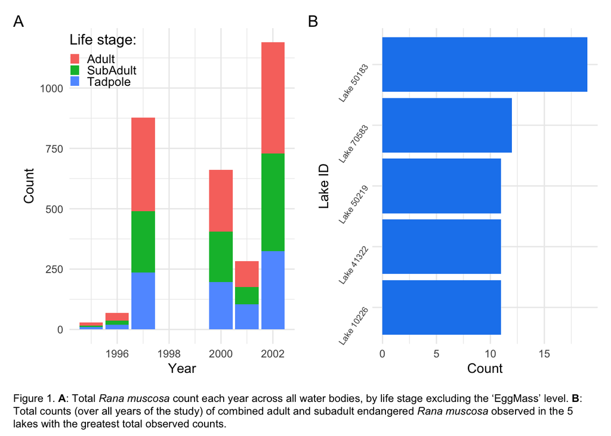

```r
patchwork <- p1 + p2
patchwork + plot_annotation(
  tag_levels = 'A',
  caption = 'Figure 1. <b>A</b>: Total <i>Rana muscosa</i> count each year across all water bodies, by life stage excluding the ‘EggMass’ level. <b>B</b>: Total counts (over all years of the study) of combined adult and subadult endangered <i>Rana muscosa</i> observed in the 5 lakes with the greatest total observed counts.',
  theme = theme(plot.caption = element_textbox_simple(margin = margin(10,0,0,0)),
        plot.caption.position = "plot"))
```